Griffin Shelor  
11-4-2024

# Homework 8: More on Pandas, Datetime, and SciPy

```python
import pandas as pd
import matplotlib.pyplot as plt
import numpy as np
from scipy.interpolate import griddata
from scipy.interpolate import interp1d
import datetime
```

## Merging data files

### Q1. Read in the files 'homework8_mag.csv' and 'homework8_nav.csv' into two different `pandas` `DataFrames`, making sure that the time column is parsed into `datetime64` format. Use `head()` to display the first 5 rows of each `DataFrame`.

[The two cells below are for each of the two `DataFrames`].

```python
## reading in csvs
mag_df = pd.read_csv('homework8_mag.csv', parse_dates=["time"])
nav_df = pd.read_csv('homework8_nav.csv', parse_dates=["time"])
## displaying first 5 rows
mag_df.head()
```

|  | time | magnetics |
| --- | --- | --- |
| 0 | 2016-02-10 00:01:00.026 | 25262.557 |
| 1 | 2016-02-10 00:02:00.027 | 25261.795 |
| 2 | 2016-02-10 00:03:00.029 | 25259.094 |
| 3 | 2016-02-10 00:04:00.030 | 25256.955 |
| 4 | 2016-02-10 00:05:00.032 | 25253.913 |

```python
nav_df.head()
```

|  | time | longitude | latitude |
| --- | --- | --- | --- |
| 0 | 2016-02-10 05:11:00 | -15.169912 | -30.222993 |
| 1 | 2016-02-10 05:12:00 | -15.168458 | -30.222885 |
| 2 | 2016-02-10 05:13:00 | -15.167002 | -30.222703 |
| 3 | 2016-02-10 05:14:00 | -15.165563 | -30.222493 |
| 4 | 2016-02-10 05:15:00 | -15.164130 | -30.222343 |

### Q2. Find the minimum 'time' value of the Q1a `DataFrame` and assign it to a variable called 'date_a', and find the minimum time value of the Q1b `DataFrame` and assign it to a variable called 'date_b'. Finally, find the minimum of 'date_a' and 'date_b' and assign this value to a variable 'date0'.

**Note**: these should be standard variables inside your notebook, not new columns inside the `DataFrame`.

```python
## finding minimum time in mag (date_a) and nav (date_b)
date_a = mag_df['time'].min()
date_b = nav_df['time'].min()

## finding total min
date0 = min(date_a, date_b)
```

### Q3. Make a column 'timediff' in each `DataFrame` that is equal to the 'time' column minus 'date0', and convert the 'timediff' columns into hours. Use `head()` to display the first 5 rows of each `DataFrame`.

[The two cells below are for each of the two `DataFrames`].

```python
## creating column for time difference from date0
mag_df['timediff'] = (mag_df['time'] - date0) / (pd.to_timedelta(1, unit = 'h'))
nav_df['timediff'] = (nav_df['time'] - date0) / (pd.to_timedelta(1, unit = 'h'))

## displaying first 5 rows of each DF
mag_df.head()
```

|  | time | magnetics | timediff |
| --- | --- | --- | --- |
| 0 | 2016-02-10 00:01:00.026 | 25262.557 | 0.000000 |
| 1 | 2016-02-10 00:02:00.027 | 25261.795 | 0.016667 |
| 2 | 2016-02-10 00:03:00.029 | 25259.094 | 0.033334 |
| 3 | 2016-02-10 00:04:00.030 | 25256.955 | 0.050001 |
| 4 | 2016-02-10 00:05:00.032 | 25253.913 | 0.066668 |

```python
nav_df.head()
```

|  | time | longitude | latitude | timediff |
| --- | --- | --- | --- | --- |
| 0 | 2016-02-10 05:11:00 | -15.169912 | -30.222993 | 5.166659 |
| 1 | 2016-02-10 05:12:00 | -15.168458 | -30.222885 | 5.183326 |
| 2 | 2016-02-10 05:13:00 | -15.167002 | -30.222703 | 5.199993 |
| 3 | 2016-02-10 05:14:00 | -15.165563 | -30.222493 | 5.216659 |
| 4 | 2016-02-10 05:15:00 | -15.164130 | -30.222343 | 5.233326 |

### Q4. This dataset was taken from a cruise where the instruments recorded navigation and magnetic data in two separate files. We can align the timing of the two files through interpolation using the workflow below. When this is finished, we will have added magnetic values to the navigation `DataFrame`.

- First, use `interp1d(...)` to fit a interpolant to the 'timediff' and 'magnetics' columns of the magnetics `DataFrame`.
- Use this fit to estimate the magnetics values at the times listed in the navigation `DataFrame`. Add these values as a new column to navigation `DataFrame`.
- Display the final results using `head()`

```python
## fitting interpolant to timediff and magnetics columns
fit = interp1d(mag_df['timediff'], mag_df['magnetics'], kind = 'linear')

## using fit to add new column of estimated magnetics values to nav_df
nav_df['magnetics'] = fit(nav_df['timediff'])

## displaying first 5 rows of nav_df
nav_df.head()
```

|  | time | longitude | latitude | timediff | magnetics |
| --- | --- | --- | --- | --- | --- |
| 0 | 2016-02-10 05:11:00 | -15.169912 | -30.222993 | 5.166659 | 24960.550703 |
| 1 | 2016-02-10 05:12:00 | -15.168458 | -30.222885 | 5.183326 | 24954.138565 |
| 2 | 2016-02-10 05:13:00 | -15.167002 | -30.222703 | 5.199993 | 24947.176901 |
| 3 | 2016-02-10 05:14:00 | -15.165563 | -30.222493 | 5.216659 | 24941.076745 |
| 4 | 2016-02-10 05:15:00 | -15.164130 | -30.222343 | 5.233326 | 24935.518594 |

### Q5. Using the data in the Navigation `DataFrame`, plot longitude (x-axis) vs. magnetic value (y-axis) using a solid line. Label the axes.

- This line crosses the Mid-Atlantic Ridge. You are seeing magnetic reversals!

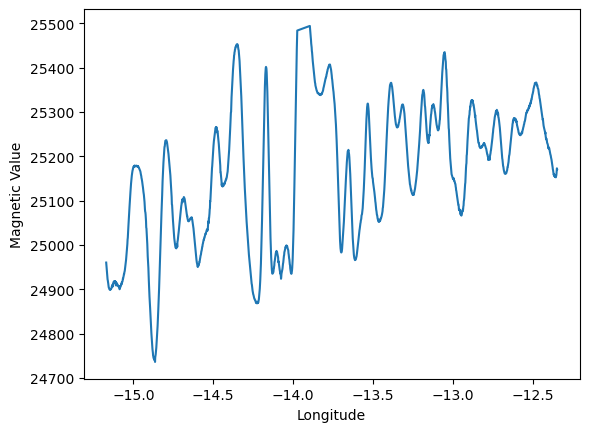

```python
## plotting longitude and magnetics
plt.plot(nav_df['longitude'], nav_df['magnetics'], '-')
plt.xlabel('Longitude')
plt.ylabel('Magnetic Value');
```

## Gridding seafloor data

### Q6. Read in the file 'homework8_seafloor_llz.txt' into three separate arrays. The first column is longitude, the second column is latitude, and the third column is depth in m.

```python
## reading in txt file, unpacking into 3 separate arrays
arr1, arr2, arr3 = np.loadtxt('homework8_seafloor_llz.txt', unpack = True)
```

### Q7. From the arrays in Q6, make two new arrays as follows. The first array 'x' should have values that go from the minimum longitude value to the maximum longitude value at a spacing of 0.001. The second array 'y' should have values that go from the minimum latitude value to the maximum latitude value at a spacing of 0.001.

```python
## making new arrays
x = np.arange(min(arr1), max(arr1), 0.001)
y = np.arange(min(arr2), max(arr2), 0.001)
```

### Q8. Use `np.meshgrid(...)` to make corresponding 2D arrays 'grid_x' and 'grid_y' from the 'x' and 'y' arrays in Q7.

```python
# Create the meshgrid
grid_x, grid_y = np.meshgrid(x, y)
```

### Q9. Make a two-column array called 'points' that has longitude in the first column and latitude in the second column from the first two arrays you read in Q6.

```python
## stacking longitude and latitude into a 2-column array
points = np.stack([arr1, arr2], axis=1)
```

### Q10. Use `griddata(...)` to grid the points using the 'cubic' method.

### Plot the resulting grid using `plt.contourf(...)`, label x and y axes, and add a colorbar with the colormap of your choice. Set the x and y tick values manually to avoid overlapping labels.

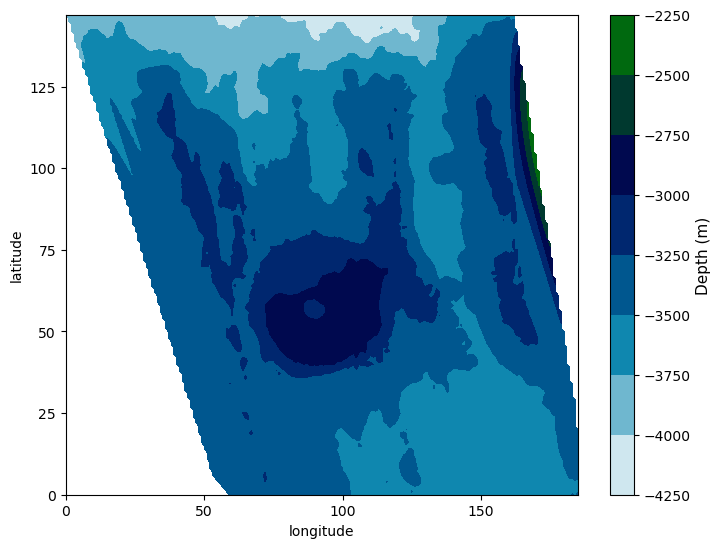

```python
# cubic interpolation
grid_cubic = griddata(points, arr3, (grid_x, grid_y), method='cubic')

## plotting grid
fig = plt.figure()
ax = fig.add_axes([1,1,1,1])
ax.set_xticks([0,50,100,150,200])
ax.set_yticks([0,25,50,75,100,125,150])
plt.contourf(grid_cubic, cmap = 'ocean_r')
plt.xlabel('longitude')
plt.ylabel('latitude')
# Make a colorbar
cb = plt.colorbar()
cb.set_label('Depth (m)', fontsize=11);
```

### Q11. Now plot the grid using `plt.imshow(...)`, add a colorbar, and use a different colormap from the one you used in Q10. Compare the result with the plot from Q10, and if needed use the `'origin'` argument so your plot has the correct orientation. Use `'extent=...'` argument to get the correct x and y axis values (in geographic units rather than pixels).

- You should see the crater of a volcano!

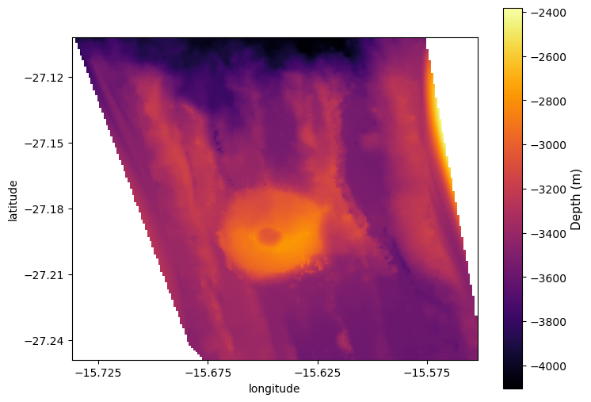

```python
# plot interpolation
fig = plt.figure()
ax = fig.add_axes([1,1,1,1])
ax.set_xticks([-15.725,-15.675,-15.625, -15.575])
ax.set_yticks([-27.24,-27.21,-27.18,-27.15, -27.12])
plt.imshow(grid_cubic, extent= (min(x), max(x), min(y), max(y)),origin='lower', cmap = 'inferno')
plt.xlabel('longitude')
plt.ylabel('latitude')
# Make a colorbar
cb = plt.colorbar()
cb.set_label('Depth (m)', fontsize=11);
```

### Q12. Make a final plot that zooms in on the volcano crater.

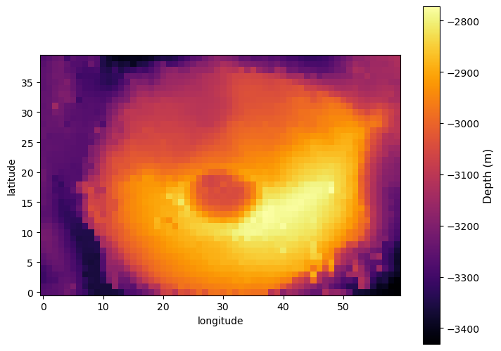

```python
## zooming in
crater_zoom = grid_cubic[40:80, 60:120]
# plot crater
fig = plt.figure()
ax = fig.add_axes([1,1,1,1])
plt.imshow(crater_zoom,origin='lower', cmap = 'inferno')
plt.xlabel('longitude')
plt.ylabel('latitude')
# Make a colorbar
cb = plt.colorbar()
cb.set_label('Depth (m)', fontsize=11);
```

### Please list any other students that you worked with on this assignment

```python
# I worked with the following students:
```

### To receive credit for this homework, upload both the .ipynb file and an .html version.